# InstaCart Exploratory Analysis: Days Since Prior Order

April Leclair, Daniel Ochoa, Hoang Anh Thai Vu, Qiuhan Sun

This file provides some exploratory analysis regarding the days_since_prior_order variable of the InstaCart data.

We know from careful consideration of the order_dow and days_since_prior_order variables that the data for each user are from consecutive orders.

# Reading In The Data

```r
orders <- read_csv("../Source/orders_sample40.csv") %>%
  mutate(order_dow = as.character(recode(order_dow, `0`="Sunday", `1`="Monday", `2`="Tuesday",
                            `3`="Wednesday", `4`="Thurday", `5`="Friday", `6`="Saturday")))
order_products <- read_csv("../Source/order_products_sample40.csv")
products <- read_csv("../Source/products.csv")
```

# Preparing The Data

Because we are primarily concerned with the `days_since_prior_order` variable we only want to consider those observations that have a value in that column. Furthermore, we only want to consider observations that are part of the `prior` evaluation set since that is the set which we will be building our model on.

```r
orders <- orders %>%
  filter(!is.na(days_since_prior_order)) %>%
  filter(eval_set == "prior") %>%
  group_by(user_id) %>%
  mutate(cumulative_days = cumsum(days_since_prior_order)) %>%  # This is going to come in useful later
  ungroup()
```

# How Long Until Users Reorder?

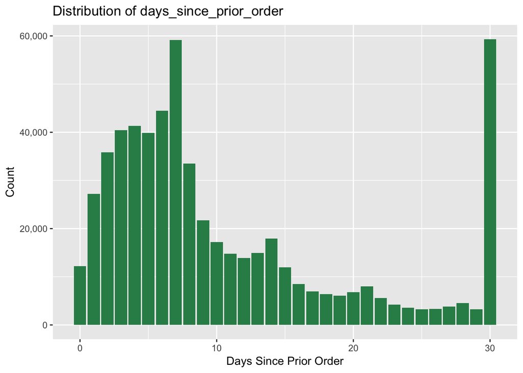

```r
orders %>%
  ggplot(aes(x=days_since_prior_order)) + geom_histogram(stat="count", fill="seagreen4") + labs(title="Distribution of days_since_prior_order", x="Days Since Prior Order", y="Count") + scale_y_continuous(labels = comma)
```

# What is the Average Number of Days Since Prior Order?

```r
orders %>%
  filter(!is.na(days_since_prior_order)) %>%
  summarise(avg = mean(days_since_prior_order))
```

```
## # A tibble: 1 x 1
##        avg
##      <dbl>
## 1 10.73004
```

It seems that on average, an InstaCart user will go approximately 11 days between orders.

# How does time since last order affect the rate of reordering

## Preparing the data

We need to join our orders table with the order_products table to have access to the reordered variable.

```r
orders_products <-
  orders %>%
  dplyr::left_join(order_products, by="order_id")  # tidyverse left_join causes discrepancy between console and knit
```

Now we construct a visualization

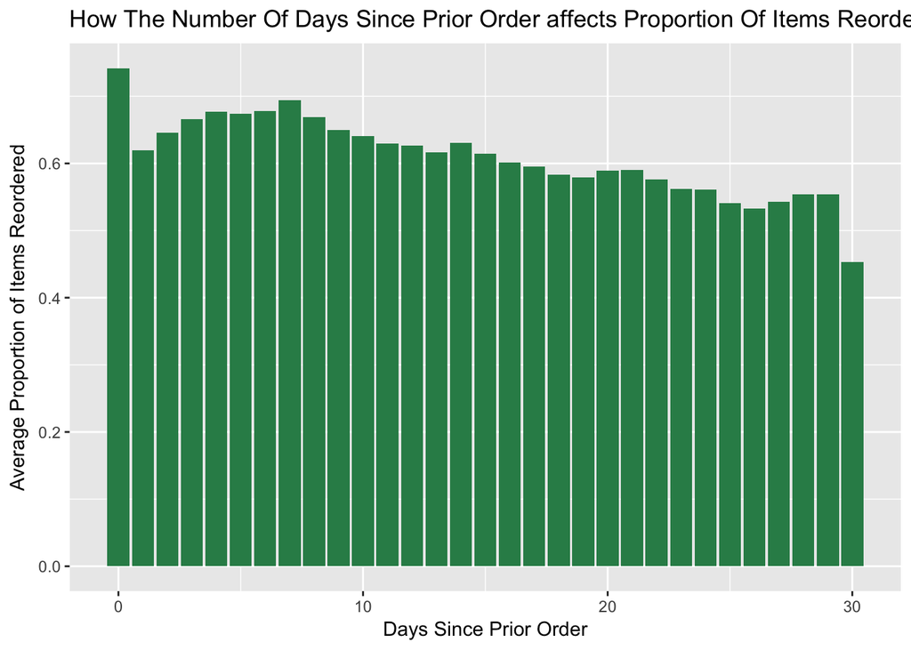

```r
orders_products %>%
  group_by(days_since_prior_order) %>%
  summarise(avg_proportion_reordered = mean(reordered)) %>%
  ggplot(aes(x=days_since_prior_order, y=avg_proportion_reordered)) + geom_col(fill="seagreen4") + labs(title="How The Number Of Days Since Prior Order affects Proportion Of Items Reordered", x="Days Since Prior Order", y="Average Proportion of Items Reordered")
```

As we can see from the plot above, in general, as the number of days since prior order increases the average proportion of items that are reorders decreases. This makes sense. If a users waits 30 days before using InstaCart again perhaps that is because the items they ordered last time were a dissapointment. They aren’t likely to reorder those items again.

# On Average, How Long Does It Take Each Product To Be Reordered?

## Preparing the data

We are going to create a variable `days_since_product_last_ordered` across each user and take the average of that, `avg_days_since_product_last_ordered` across all observations.

```r
orders_products_daysSinceProductLastOrdered <-
  orders_products %>%
  group_by(user_id) %>%
  mutate(days_since_product_last_ordered = stats::ave(cumulative_days, product_id, FUN=function(x) c(0, diff(x)))) %>%
  ungroup() %>%
  filter(!days_since_product_last_ordered == 0) %>%  # Filter out first time buying item
  group_by(product_id) %>%
  summarise(avg_days_since_product_last_ordered = mean(days_since_product_last_ordered)) %>%
  inner_join(products, by="product_id") %>%  # For product names
  arrange(avg_days_since_product_last_ordered)
```

Since we want to display the product names and we don’t want a cluttered visualization we only consider the top and bottom 20 products.

```r
highest20 <- tail(orders_products_daysSinceProductLastOrdered, 20)
lowest20 <- head(orders_products_daysSinceProductLastOrdered, 20)
```

[figure not shown]

```r
ggplot(data=lowest20, aes(x=product_id, y=avg_days_since_product_last_ordered)) + geom_point(alpha=0.05) + geom_text_repel(aes(label=product_name), color="seagreen4") + labs(title="The 20 Products With The Lowest Average Days Since Last Order", x="Product ID", y="Average Days Since Product Was Last Ordered")
```

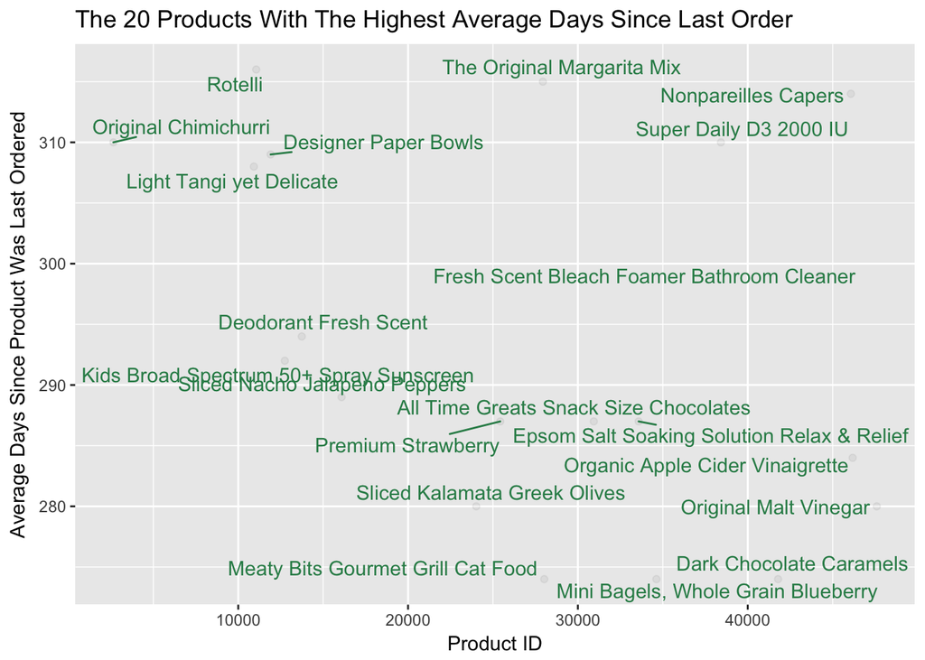

```r
ggplot(data=highest20, aes(x=product_id, y=avg_days_since_product_last_ordered)) + geom_point(alpha=0.05) + geom_text_repel(aes(label=product_name), color="seagreen4") + labs(title="The 20 Products With The Highest Average Days Since Last Order", x="Product ID", y="Average Days Since Product Was Last Ordered")
```